# 03_Class_Activity

# Part 3: From Histograms to Density Plots

Density plots give us a smoothed version of the histogram:

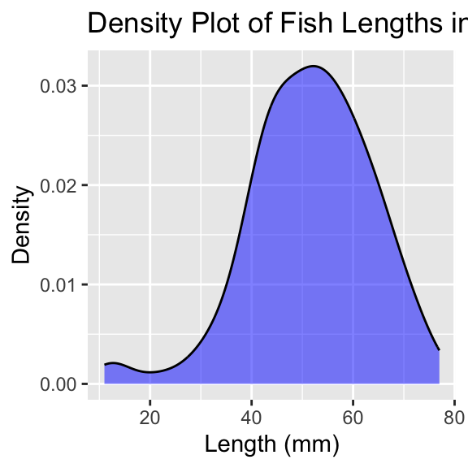

```r
# Create a density plot
sculpin_df %>%
  filter(lake == "Toolik") %>%
  ggplot(aes(x = length_mm)) +
  geom_density(fill = "blue", alpha = 0.5) +
  labs(title = "Density Plot of Fish Lengths in Toolik Lake",
       x = "Length (mm)",
       y = "Density")
```

We can overlay the histogram and the density plot:

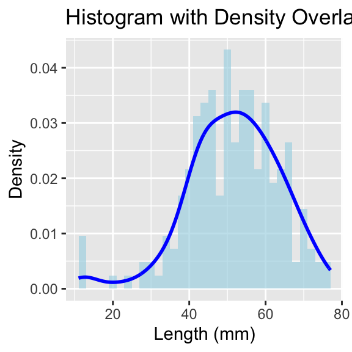

```r
# Combine histogram and density plot
sculpin_df %>%
  filter(lake == "Toolik") %>%
  ggplot(aes(x = length_mm)) +
  geom_histogram(aes(y = after_stat(density)), binwidth = 2,
                 fill = "lightblue", alpha = 0.7) +
  geom_density(color = "blue", linewidth = 1) +
  labs(title = "Histogram with Density Overlay",
       x = "Length (mm)",
       y = "Density")
```

**Activity 4**

Create a density plot comparing multiple lakes. Which lakes have similar distributions? Which ones are different?

Try code here using patchwork or facet_grid

```r
 #Enter code here#
```

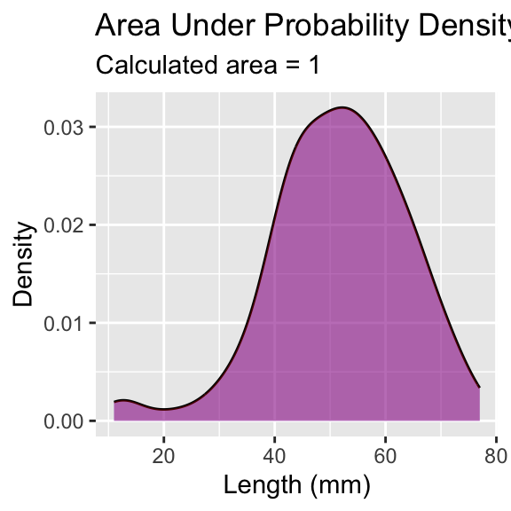

```r
# Function to calculate area under density curve
calculate_density_area <- function(data_vector) {
  # Remove NA values
  data_vector <- data_vector[!is.na(data_vector)]

  # Calculate density
  dens <- density(data_vector)

  # Calculate area using numeric integration (trapezoidal rule)
  # Area should be approximately 1
  dx <- diff(dens$x)
  y_avg <- (dens$y[-1] + dens$y[-length(dens$y)]) / 2
  area <- sum(dx * y_avg)
  return(area)
}

# Apply to Toolik lake data
toolik_data <- sculpin_df %>%
  filter(lake == "Toolik") %>%
  pull(length_mm)

area_value <- calculate_density_area(toolik_data)

# Create plot with calculated area
sculpin_df %>%
  filter(lake == "Toolik") %>%
  ggplot(aes(x = length_mm)) +
  geom_density(fill = "blue", alpha = 0.4) +
  geom_area(stat = "density", fill = "red", alpha = 0.3) +
  labs(title = "Area Under Probability Density Function = 1",
       subtitle = paste("Calculated area =", round(area_value, 4)),
       x = "Length (mm)",
       y = "Density")
```

This can be adapted to calculate the area of a subset of the plot

I don’t expect you to know or be able to do all of this but is here to play with the code

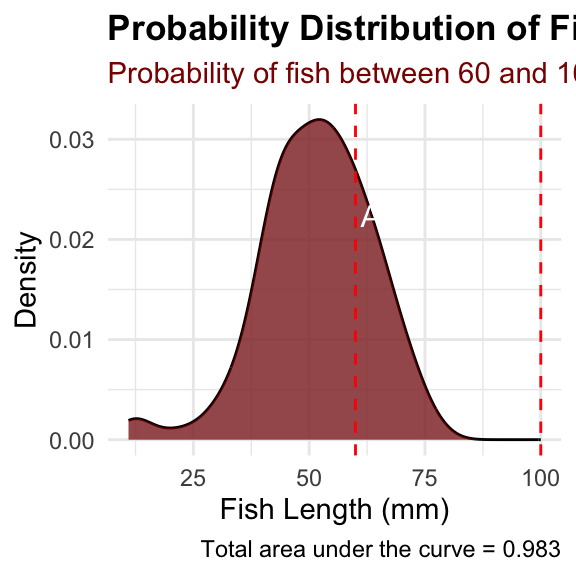

```r
# ------- PART 3: SET STUDENT INPUT VALUES -------
# Students can change these values to calculate different probabilities

# For this example, let's calculate the probability of fish between 40mm and 60mm
lower_bound <- 60  # Student would change this value
upper_bound <- 100  # Student would change this value



# ------- PART 1: PREPARE THE DATA -------

# Filter data for just one lake to keep it simple for students
toolik_fish <- sculpin_df %>%
  filter(lake == "Toolik") %>%
  filter(!is.na(length_mm))  # Remove any missing values

# ------- PART 2: CREATE A FUNCTION TO CALCULATE PROBABILITY -------

# This function calculates the probability of finding a fish with length between
# lower_bound and upper_bound using the empirical distribution of our data
calculate_probability <- function(data_vector, lower_bound, upper_bound) {
  # First, we create a density object from our data
  dens <- density(data_vector)

  # Find indices of x-values that fall within our bounds
  indices <- which(dens$x >= lower_bound & dens$x <= upper_bound)

  # If we have no points in the range, return 0
  if(length(indices) <= 1) {
    return(0)
  }

  # Get x and y values within our bounds
  x_values <- dens$x[indices]
  y_values <- dens$y[indices]

  # Calculate the area using the trapezoidal rule
  # (average height × width) for each segment, then sum all segments
  widths <- diff(x_values)
  avg_heights <- (y_values[-1] + y_values[-length(y_values)]) / 2
  area_in_range <- sum(widths * avg_heights)

  # Return the calculated probability
  return(area_in_range)
}


# ------- PART 4: CALCULATE THE PROBABILITY -------

# Calculate the probability for the specified range
probability <- calculate_probability(toolik_fish$length_mm, lower_bound, upper_bound)

# Calculate the total area to show that the complete distribution sums to approximately 1
total_area <- calculate_probability(toolik_fish$length_mm,
                                   min(toolik_fish$length_mm),
                                   max(toolik_fish$length_mm))

# ------- PART 5: CREATE THE VISUALIZATION -------

# Create a plot showing the full distribution and the selected range
ggplot(toolik_fish, aes(x = length_mm)) +
  # First, plot the overall density curve
  geom_density(fill = "lightblue", alpha = 0.5) +

  # Then highlight our region of interest in a different color
  geom_area(stat = "density",
            fill = "darkred",
            alpha = 0.7,
            xlim = c(lower_bound, upper_bound)) +

  # Add vertical lines to clearly mark the boundaries
  geom_vline(xintercept = lower_bound, linetype = "dashed", color = "red") +
  geom_vline(xintercept = upper_bound, linetype = "dashed", color = "red") +

  # Add informative labels
  labs(
    title = "Probability Distribution of Fish Lengths",
    subtitle = paste0("Probability of fish between ", lower_bound,
                     " and ", upper_bound, " mm = ",
                     round(probability * 100, 1), "%"),
    caption = paste("Total area under the curve =", round(total_area, 3)),
    x = "Fish Length (mm)",
    y = "Density"
  ) +

  # Add text annotations to explain the areas
  annotate("text", x = (lower_bound + upper_bound)/2,
           y = max(density(toolik_fish$length_mm)$y) * 0.7,
           label = paste0("Area = ", round(probability, 3)),
           color = "white", size = 4) +

  # Make the plot look nicer
  theme_minimal() +
  theme(
    plot.title = element_text(face = "bold"),
    plot.subtitle = element_text(color = "darkred")
  )
```

# Part 4: Summary Statistics - descriptive statistics

Let’s calculate basic summary statistics for each lake:

```r
# Calculate mean, standard deviation, and sample size by lake
sculpin_df %>%
  group_by(lake) %>%
  summarize(
    mean_length = mean(length_mm),
    sd_length = sd(length_mm),
    count = n(),
    .groups = "drop"
  ) %>%
  arrange(desc(count))
```

```
# A tibble: 7 × 4
  lake   mean_length sd_length count
  <chr>        <dbl>     <dbl> <int>
1 Toolik        NA        NA     287
2 E 01          NA        NA     268
3 NE 12         49.8      15.2   180
4 S 06          54.0      10.9   132
5 E 05          NA        NA      75
6 S 07          55.6      12.7    73
7 NE 14         47.3      10.5    37
```

## WOAH - what happened there - there are NA values in the data

you need to either remove missing values or you can do that in the formulas

*What is the advantage to manually removing or doing it in formulas?*

```r
# Calculate mean, standard deviation, and sample size by lake
sculpin_stats_df <- sculpin_df %>%
  group_by(lake) %>%
  summarize(
    mean_length = mean(length_mm, na.rm = TRUE),
    sd_length = sd(length_mm, na.rm = TRUE),
    se_length = sd(length_mm, na.rm = TRUE)/ sum(!is.na(length_mm))^.5,
    count = sum(!is.na(length_mm)),
    .groups = "drop"
  ) %>%
  arrange(desc(count))
sculpin_stats_df
```

```
# A tibble: 7 × 5
  lake   mean_length sd_length se_length count
  <chr>        <dbl>     <dbl>     <dbl> <int>
1 Toolik        51.7      12.0     0.834   208
2 NE 12         49.8      15.2     1.13    180
3 S 06          54.0      10.9     0.949   132
4 E 01          58.2      15.3     1.72     79
5 S 07          55.6      12.7     1.48     73
6 NE 14         47.3      10.5     1.72     37
7 E 05          47.1      10.8     2.88     14
```

Now let’s visualize these statistics:

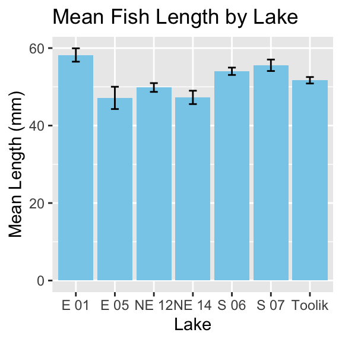

```r
# Create a bar plot of mean lengths with error bars
sculpin_df %>%
  ggplot(aes(lake, length_mm)) +
  stat_summary(
    fun = mean, na.rm = TRUE,
    geom = "bar",
    fill = "skyblue"
    ) +
  stat_summary(
    fun.data = mean_se, na.rm = TRUE,
    geom = "errorbar",
    width = 0.2) +
  labs(title = "Mean Fish Length by Lake",
       x = "Lake",
       y = "Mean Length (mm)")
```

We could also do this from the dataframe we just made

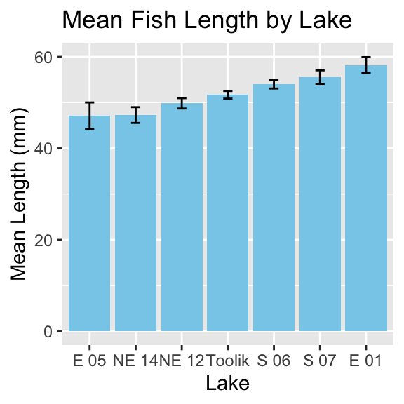

```r
# Create a bar plot of mean lengths with error bars
sculpin_stats_df %>%
  ggplot(aes(x = reorder(lake, mean_length), y = mean_length)) +
  geom_bar(stat = "identity",
           fill = "skyblue") +
  geom_errorbar(aes(
    ymin = mean_length - se_length,
    ymax = mean_length + se_length),
    width = 0.2
    ) +
  labs(
    title = "Mean Fish Length by Lake",
       x = "Lake",
       y = "Mean Length (mm)")
```

The power of the pipe command is you can do this without hving to make a new dataframe

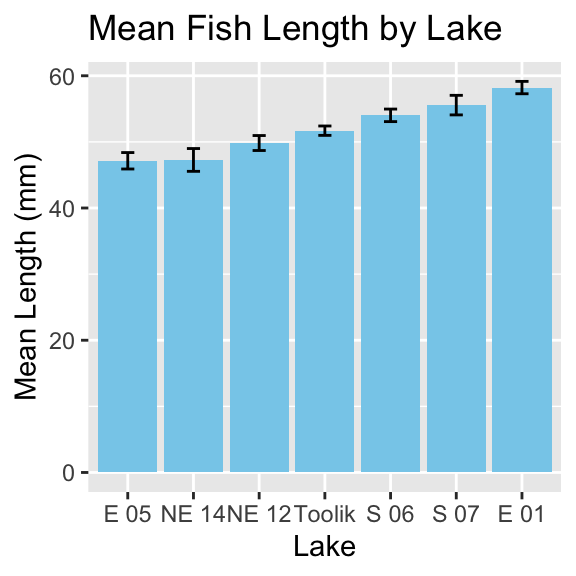

```r
# Create a bar plot of mean lengths with error bars
sculpin_df %>%
  group_by(lake) %>%
  summarize(
    mean_length = mean(length_mm, na.rm = TRUE),
    sd_length = sd(length_mm, na.rm = TRUE),
    se_length = sd_length / sqrt(n()),
    count = n(),
    .groups = "drop"
  ) %>%
  filter(count >= 10) %>%  # Only include lakes with sufficient sample size
  ggplot(aes(x = reorder(lake, mean_length), y = mean_length)) +
  geom_bar(stat = "identity", fill = "skyblue") +
  geom_errorbar(aes(ymin = mean_length - se_length,
                    ymax = mean_length + se_length),
                width = 0.2) +
  labs(title = "Mean Fish Length by Lake",
       x = "Lake",
       y = "Mean Length (mm)")
```

**Activity 5**

Based on the mean plot and what you’ve seen in the distributions, what can you say about fish sizes in different lakes? Are there lakes with particularly large or small fish?

We will start to ask how different are they and is it by chance?

This is the inductive phase of doing research.

# Part 5: Guided Challenges

Now it’s your turn to explore the data! Work with your partner to complete these challenges:

1. Find the lake with the widest range of fish lengths (hint: use the `range()` function)
2. Create box and whisker plots to compare fish lengths across lakes:

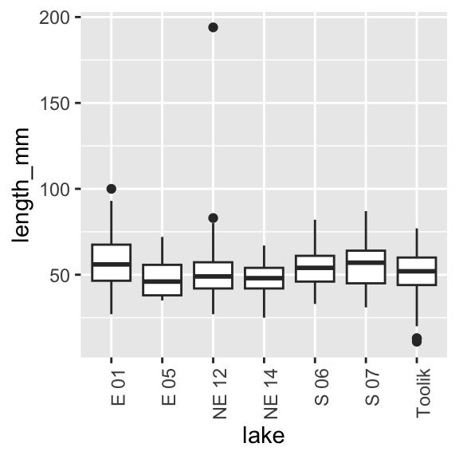

```r
# Example boxplot code to get you started
sculpin_df %>%
  filter(!is.na(length_mm)) %>%
  ggplot(aes(x = lake, y = length_mm)) +
  geom_boxplot() +
  theme(axis.text.x = element_text(angle = 90, hjust = 1))
```

3. Explore if there’s a relationship between fish length and mass:

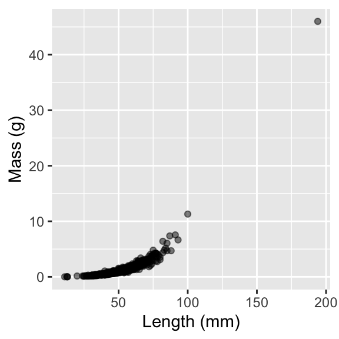

```r
# Starting code for length-mass relationship
sculpin_df %>%
  filter(!is.na(length_mm), !is.na(mass_g)) %>%
  ggplot(aes(x = length_mm, y = mass_g)) +
  geom_point(alpha = 0.5) +
  labs(x = "Length (mm)", y = "Mass (g)")
```

4. Try creating a density plot that shows all lakes in different colors:

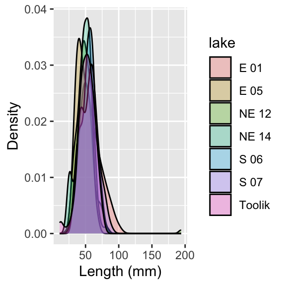

```r
# Starting code for multi-lake density plot
sculpin_df %>%
  filter(!is.na(length_mm)) %>%
  ggplot(aes(x = length_mm, fill = lake)) +
  geom_density(alpha = 0.3) +
  labs(x = "Length (mm)", y = "Density")
```

# Reflection Questions

After completing the activities, discuss these questions with your group:

1. How does sample size affect our view of a population’s characteristics?
2. Why might fish lengths be different in different lakes?
3. What are the advantages and disadvantages of histograms versus density plots?
4. What additional data would help you better understand these fish populations?

Back to top